# Simulation Description

Alex

2022-09-15

## Simulation Scenario I

### Description of multivariate association structure

This simple simulation scenario has a relatively simple random effects structure (correlated random intercepts / slopes) on six dimensions. The idea behind the covariance matrix:

- Auto-covariance is random intercept and random slope with negative covariance $\mathbf A = \begin{pmatrix} 0.08 & -0.07 \\ -0.07 & 0.90 \\ \end{pmatrix}$
- Auto-covariance is different between the markers: Larger auto-covariance for later markers, so multiply $\mathbf A$ by factors $1, 1.2, 1.4, 1.6, 1.8, 2)$
- Cross-covariance is a matrix $\mathbf B = \begin{pmatrix} 0.03 & 0.03 \\ 0.03 & 0.03 \\ \end{pmatrix}$ times a correlation function $f$ regarding the distance $x \in \{1, 2, 3, 4, 5\}$ between markers with $f(x) = \begin{cases}1 & x == 1\\ 0.75 & x == 2 \\ 0.5 & x == 3 \\ 0 & else\end{cases}$

This gives the following covariance matrix

```r
# Covariance matrix for the data generation
auto <- matrix(c(0.08, -0.07, -0.07, 0.9), ncol = 2)
cross <- matrix(rep(0.03, 4), ncol = 2)
cor <- matrix(c(0, 1, 0.75, 0.5, 0, 0,
                1, 0, 1, 0.75, 0.5, 0,
                0.75, 1, 0, 1, 0.75, 0.5,
                0.5, 0.75, 1, 0, 1, 0.75,
                0, 0.5, 0.75, 1, 0, 1,
                0, 0, 0.5, 0.75, 1, 0),
              ncol = 6)
cov <- kronecker(cor, cross) + kronecker(diag(c(1, 1.2, 1.4, 1.6, 1.8, 2)),
                                         auto)
tril(cov)
```

```
## 12 x 12 Matrix of class "dtrMatrix"
##       [,1]    [,2]    [,3]    [,4]    [,5]    [,6]    [,7]    [,8]    [,9]
##  [1,]  0.0800       .       .       .       .       .       .       .       .
##  [2,] -0.0700  0.9000       .       .       .       .       .       .       .
##  [3,]  0.0300  0.0300  0.0960       .       .       .       .       .       .
##  [4,]  0.0300  0.0300 -0.0840  1.0800       .       .       .       .       .
##  [5,]  0.0225  0.0225  0.0300  0.0300  0.1120       .       .       .       .
##  [6,]  0.0225  0.0225  0.0300  0.0300 -0.0980  1.2600       .       .       .
##  [7,]  0.0150  0.0150  0.0225  0.0225  0.0300  0.0300  0.1280       .       .
##  [8,]  0.0150  0.0150  0.0225  0.0225  0.0300  0.0300 -0.1120  1.4400       .
##  [9,]  0.0000  0.0000  0.0150  0.0150  0.0225  0.0225  0.0300  0.0300  0.1440
## [10,]  0.0000  0.0000  0.0150  0.0150  0.0225  0.0225  0.0300  0.0300 -0.1260
## [11,]  0.0000  0.0000  0.0000  0.0000  0.0150  0.0150  0.0225  0.0225  0.0300
## [12,]  0.0000  0.0000  0.0000  0.0000  0.0150  0.0150  0.0225  0.0225  0.0300
##       [,10]   [,11]   [,12]
##  [1,]       .       .       .
##  [2,]       .       .       .
##  [3,]       .       .       .
##  [4,]       .       .       .
##  [5,]       .       .       .
##  [6,]       .       .       .
##  [7,]       .       .       .
##  [8,]       .       .       .
##  [9,]       .       .       .
## [10,]  1.6200       .       .
## [11,]  0.0300  0.1600       .
## [12,]  0.0300 -0.1400  1.8000
```

With the constant and linear basis functions, the corresponding multivariate functional principal components can be computet. We keep $7$ MFPCs to account for more than $95\%$ of the variation.

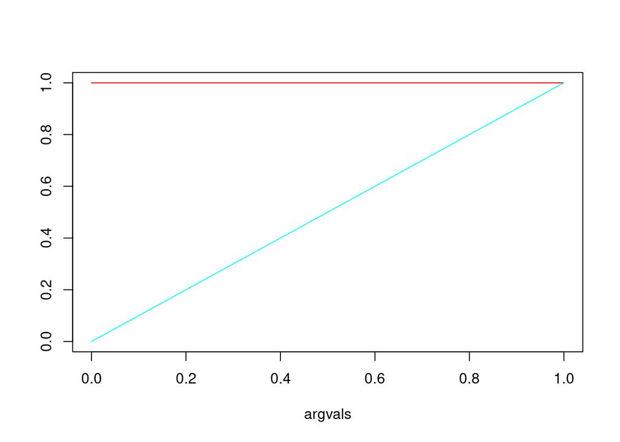

```r
# Basis functions on each dimension
seq1 <- seq(0, 1, by = 0.01)
b_funs <- rep(list(funData(argvals = seq1,
                           X = matrix(c(rep(1, length(seq1)), seq1),
                                      byrow = TRUE, ncol = length(seq1)))), 6)
plot(b_funs[[1]])
```

```r
# Compute the MPFCs for a given covariance matrix of the basis coefficients
mfpca_tru <- MFPCA_cov(cov = cov, basis_funs = b_funs)

# Use a cutoff of 95%
cumsum(mfpca_tru$values) / sum(mfpca_tru$values)
```

```
##  [1] 0.2490633 0.4383820 0.6015916 0.7392255 0.8529344 0.9421509 0.9578692
##  [8] 0.9698261 0.9799567 0.9883548 0.9950926 1.0000000
```

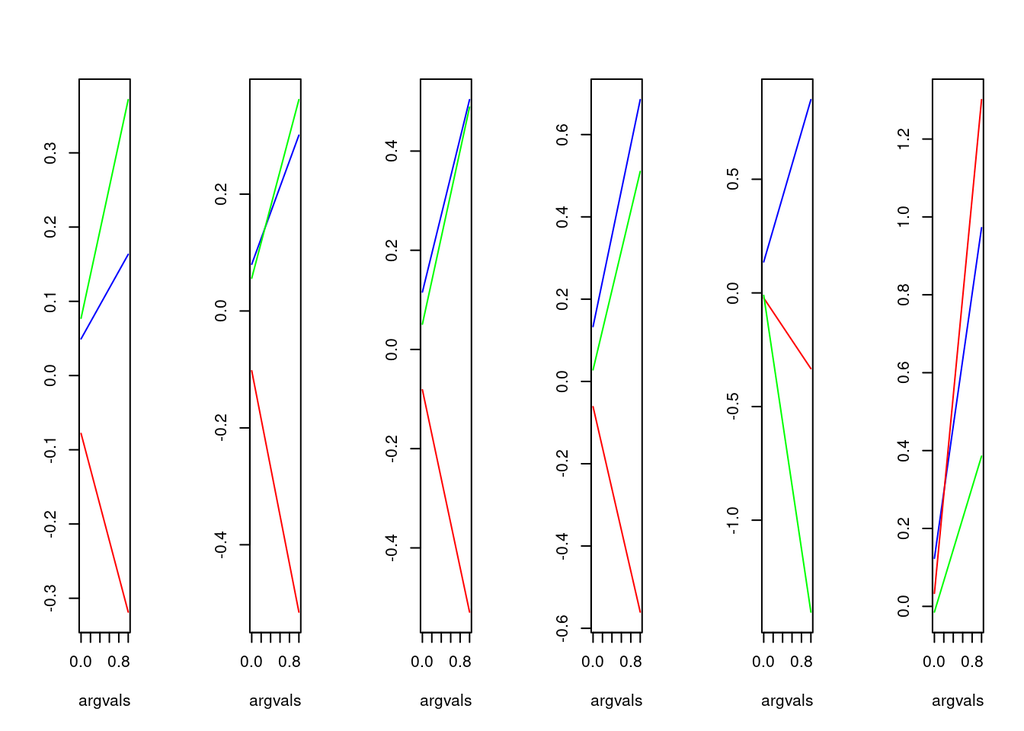

```r
# First three and 4-7
plot(extractObs(mfpca_tru$functions, 1:3), col = c("blue", "red", "green"))
```

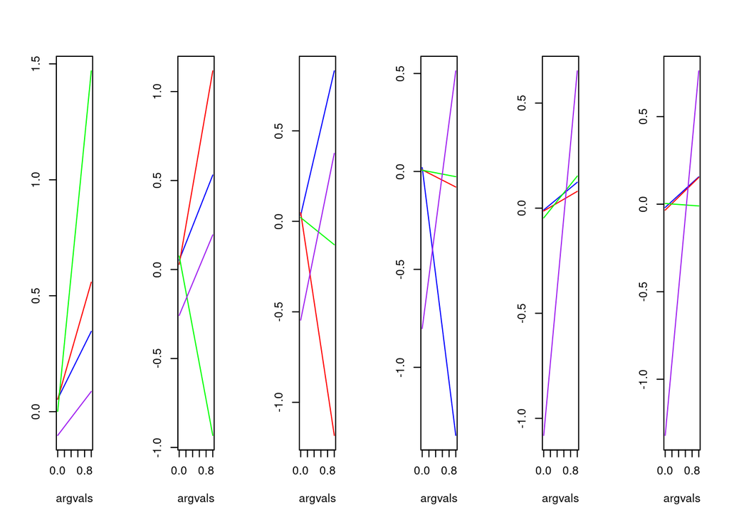

```r
plot(extractObs(mfpca_tru$functions, 4:7),
     col = c("blue", "red", "green", "purple"))
```

### Description of the simulation set up

The simulation is similar to Koehler et al. (2017), meaning censoring and longitudinal observations follow a similar scheme and the survival times are simulated also following Bender et al. (2005). Some of the specifications for this scenario are the following:

- $150$ individuals
- $6$ markers
- Observation times on interval $[0, 1]$ where baseline measurement at $0$ are available for all individuals on all markers
- Longitudinal measurements are available on a fixed grid of $101$ timepoints but only up to $75\%$ are retained with a maximum of $15$ observation per individual and marker
- Baseline hazard follows a Weibull distribution $h(t) = 1.37 \cdot t^{0.37}$ but is scaled down by an intercept in the $\gamma$-predictor
- Censoring is based on a uniform distribution $Unif(0, 1.75)$

Especially the maximum number of longitudinal observation points reduces the computation time (from around $8$ to $2.5$ hours).

The additive predictors are specified as follows
$$\begin{align}
\eta_{\lambda} &= 1.37 \cdot t^{0.37}
\end{align}$$
$$\begin{align}
\eta_{\gamma i} &= -1.5 + 0.48*x_i
\end{align}$$
$$\begin{align}
\eta_{\mu k i} &= 0.2\cdot t - 0.25 \cdot x_i - 0.05 \cdot t \cdot
x_i +
b_{k1i} + b_{k2i} \cdot t , \quad k = 1,...,
6
\end{align}$$
$$\begin{align}
\eta_{\alpha k} = \begin{cases}
1.5 & k = 1\\ 0.6 & k = 2 \\ 0.3 & k = 3 \\
-0.3 & k = 4 \\ -0.6 & k = 5\\ -1.5 & k = 6
\end{cases}
\end{align}$$
$$\begin{align}
\eta_{\sigma} = log(0.06)
\end{align}$$
with $x$ a binary covariate. This means that the error variance is constant over all markers but the random effects vary.

### Summary description of simulated data sets

For the 100 simulated data sets, we have a mean of about 9500 observation per data set.

```
##    Min. 1st Qu.  Median    Mean 3rd Qu.    Max.
##    8569    9214    9424    9458    9700   10140
```

Over all the simulated data sets, the mean individual has 63 observation points (total sum over all 6 dimensions).

```
##    Min. 1st Qu.  Median    Mean 3rd Qu.    Max.
##    6.00   38.00   73.00   63.06   90.00   90.00
```

The mean event rate of a simulated data set is about $43\%$.

The mean survival time over all indidviduals and all simulated data sets is about $0.5$.

```
##        Min.     1st Qu.      Median        Mean     3rd Qu.        Max.
## 0.006314305 0.224350094 0.467120709 0.515718145 0.838116569 1.000000000
```

For the individuals who experience an event, however, the mean survival time is at about $0.4$.

```
##       Min.    1st Qu.     Median       Mean    3rd Qu.       Max.
## 0.01175071 0.18397661 0.35627995 0.38678945 0.55770526 0.95153311
```

### Plots of a random simulated data set

The following plots give an impression of the survival part of the simulated data. First, a Kaplan Meier plot stratified by the covariate $x$ and second, a plot of the individual survival times.

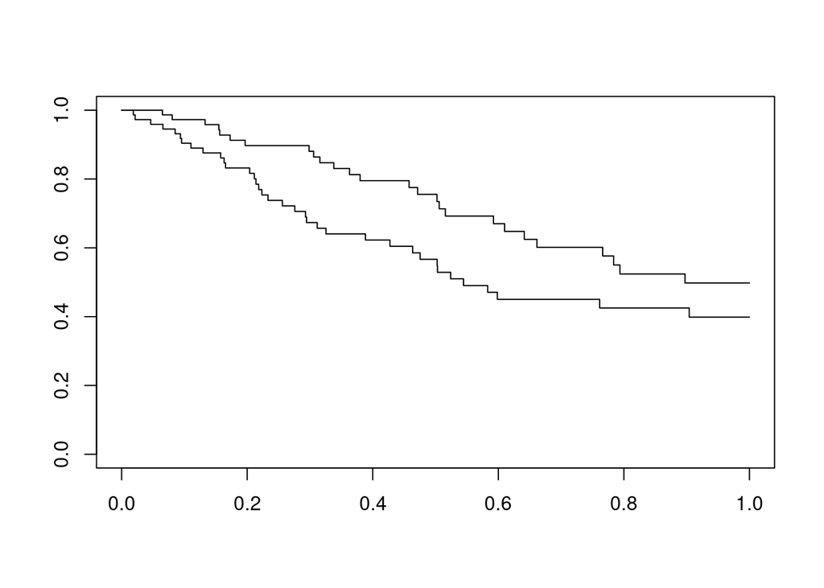

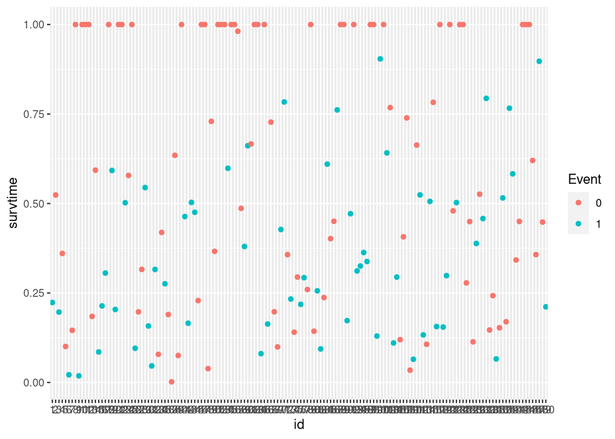

The following plot shows the generated longitudinal trajectories (with noise).

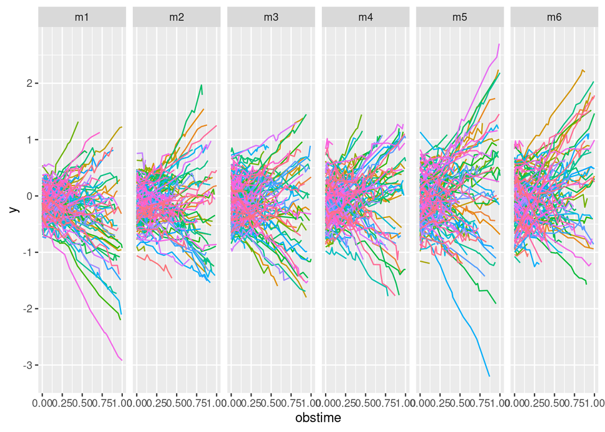

The following plot shows the hypothetical longitudinal trajectories (without noise) of those individuals that experience an event.

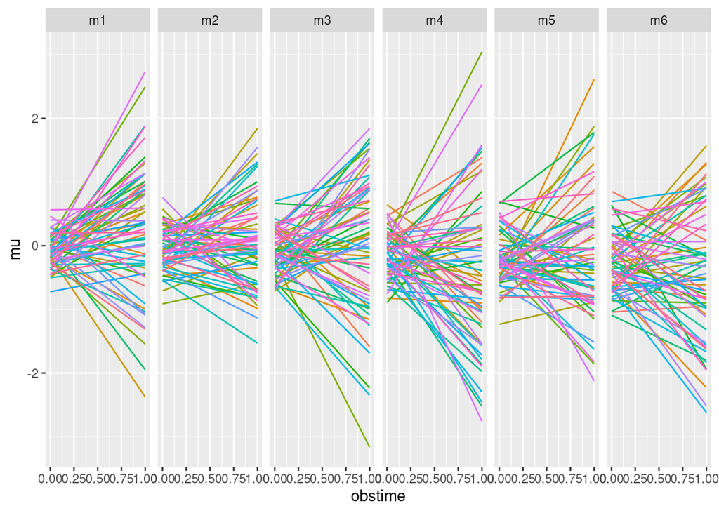